# Homework 4.1

- Luis Fernando Márquez Bañuelos
- Luis Eduardo Jiménez del Muro
- Diego Lozoya Morales

```python
import numpy as np
import pandas as pd
import matplotlib.pyplot as plt
import yfinance as yf
from scipy import stats
from Fitter import Fitter, get_common_distributions, get_distributions;

plt.rcParams['figure.facecolor'] = 'lightgrey'
plt.rcParams['figure.figsize'] = (12, 6)
plt.rcParams['axes.grid'] = True
plt.rcParams['grid.alpha'] = 0.5
plt.rcParams['grid.linestyle'] = '--'
plt.rcParams['axes.titlesize'] = 16
plt.rcParams['axes.labelsize'] = 12
plt.rcParams['legend.frameon'] = True
plt.rcParams['legend.facecolor'] = 'white'
plt.rcParams['legend.edgecolor'] = 'black'

colors = ["cornflowerblue", "indianred", "darkseagreen", "plum", "dimgray"]
```

# Data

```python
data = yf.download("AAPL", start="2001-01-01", end="2025-09-01")["Close"]
data
```

```
[*********************100%***********************]  1 of 1 completed
```

| Ticker Date | AAPL |
| --- | --- |
| 2001-01-02 | 0.223275 |
| 2001-01-03 | 0.245790 |
| 2001-01-04 | 0.256110 |
| 2001-01-05 | 0.245790 |
| 2001-01-08 | 0.248604 |
| ... | ... |
| 2025-08-25 | 227.160004 |
| 2025-08-26 | 229.309998 |
| 2025-08-27 | 230.490005 |
| 2025-08-28 | 232.559998 |
| 2025-08-29 | 232.139999 |

6202 rows × 1 columns

# Price plot

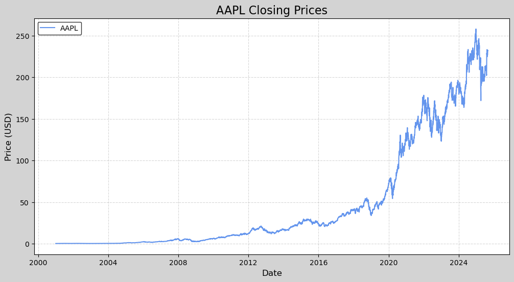

```python
plt.figure()
plt.plot(data, color=colors[0], label="AAPL")
plt.title("AAPL Closing Prices")
plt.xlabel("Date")
plt.ylabel("Price (USD)")
plt.legend()
plt.show()
```

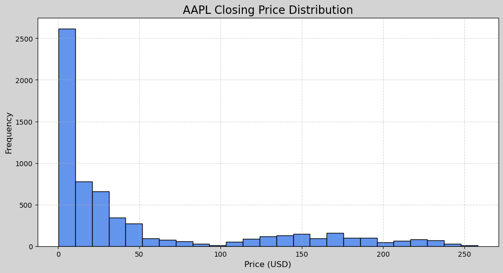

```python
plt.figure()
plt.hist(data.dropna(), bins=25, color=colors[0], edgecolor='black')
plt.title("AAPL Closing Price Distribution")
plt.xlabel("Price (USD)")
plt.ylabel("Frequency")
plt.show()
```

# Return plot

```python
data["R"] = data["AAPL"].pct_change().dropna()
data["r"] = np.log(data["AAPL"]) - np.log(data["AAPL"].shift(1))

data = data.dropna()
```

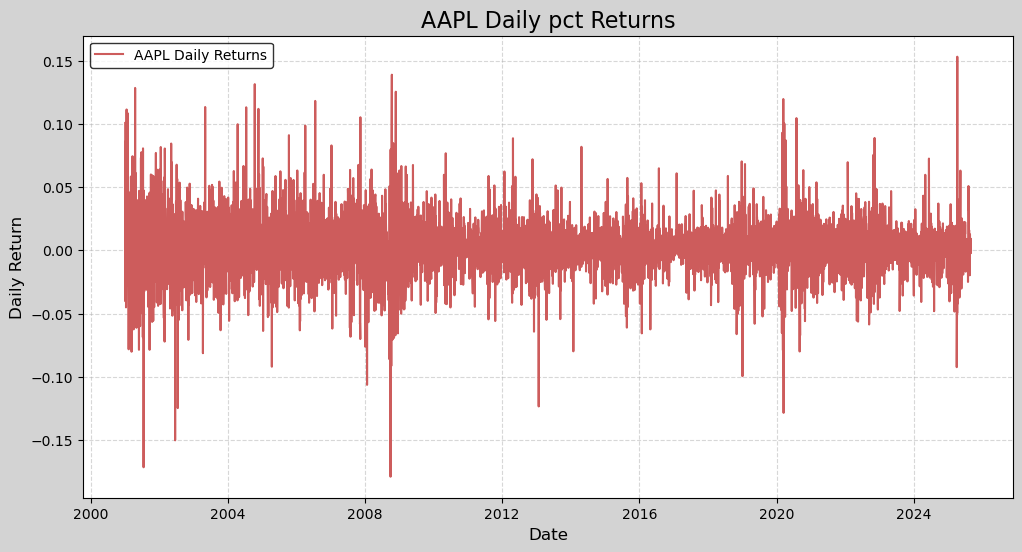

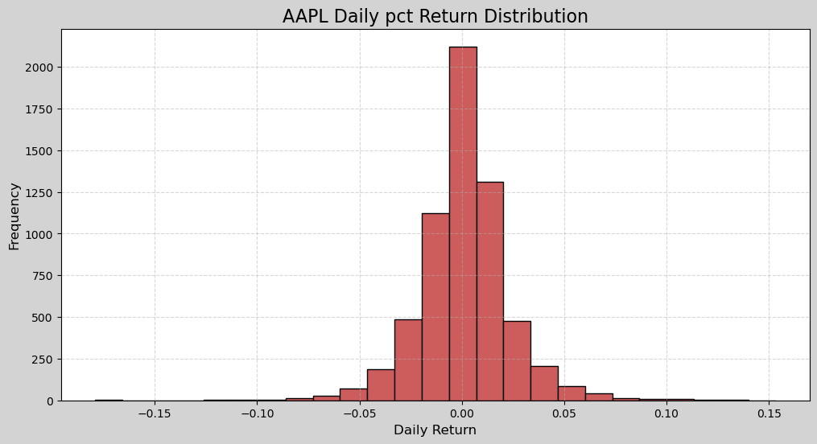

```python
plt.figure()
plt.plot(data["R"], color=colors[1], label="AAPL Daily Returns")
plt.title("AAPL Daily pct Returns")
plt.xlabel("Date")
plt.ylabel("Daily Return")
plt.legend()
plt.show()

plt.figure()
plt.hist(data["R"], bins=25, color=colors[1], edgecolor='black')
plt.title("AAPL Daily pct Return Distribution")
plt.xlabel("Daily Return")
plt.ylabel("Frequency")
plt.show()
```

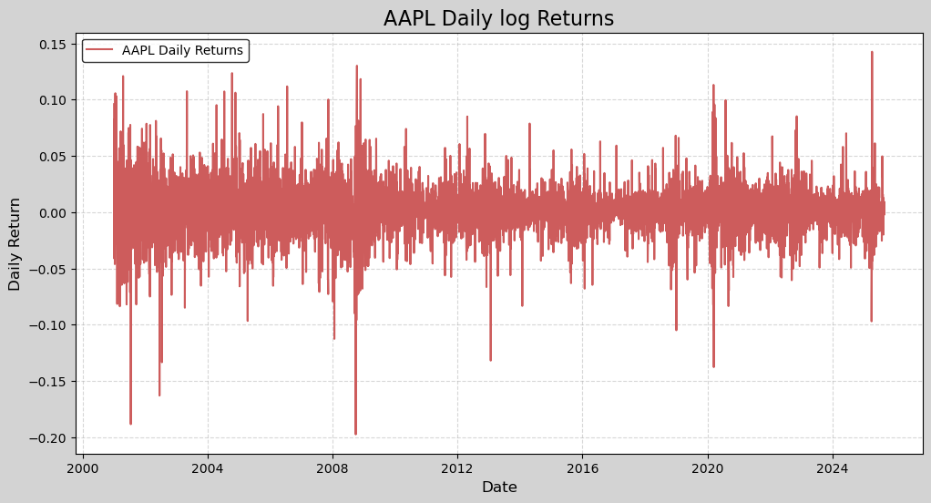

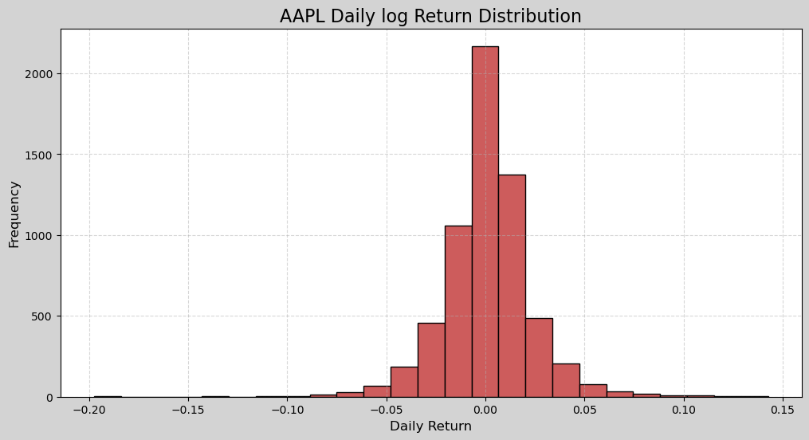

```python
plt.figure()
plt.plot(data["r"], color=colors[1], label="AAPL Daily Returns")
plt.title("AAPL Daily log Returns")
plt.xlabel("Date")
plt.ylabel("Daily Return")
plt.legend()
plt.show()

plt.figure()
plt.hist(data["r"], bins=25, color=colors[1], edgecolor='black')
plt.title("AAPL Daily log Return Distribution")
plt.xlabel("Daily Return")
plt.ylabel("Frequency")
plt.show()
```

# Report

```python
def dqr(data):

    cols = pd.DataFrame(list(data.columns.values),
                           columns=['Name'],
                           index=list(data.columns.values))
    dtyp = pd.DataFrame(data.dtypes,columns=['Type'])
    misval = pd.DataFrame(data.isnull().sum(),
                                  columns=['N/A value'])
    presval = pd.DataFrame(data.count(),
                                  columns=['Count values'])
    unival = pd.DataFrame(columns=['Unique values'])
    minval = pd.DataFrame(columns=['Min'])
    maxval = pd.DataFrame(columns=['Max'])
    mean =pd.DataFrame(data.mean(), columns=['Mean'])
    Std =pd.DataFrame(data.std(), columns=['Std'])
    Var =pd.DataFrame(data.var(), columns=['Var'])
    median =pd.DataFrame(data.median(), columns=['Median'])

    skewness = pd.DataFrame(data.skew(), columns=['Skewness'])
    kurtosis = pd.DataFrame(data.kurtosis(), columns=['Kurtosis'])

    for col in list(data.columns.values):
        unival.loc[col] = [data[col].nunique()]
        try:
            minval.loc[col] = [data[col].min()]
            maxval.loc[col] = [data[col].max()]
        except:
            pass

    # Juntar todas las tablas
    return cols.join(dtyp).join(misval).join(presval).join(unival).join(minval).join(maxval).join(mean).join(Std).join(Var).join(median).join(skewness).join(kurtosis)
```

```python
Report= dqr(data)
Report
```

|  | Name | Type | N/A value | Count values | Unique values | Min | Max | Mean | Std | Var | Median | Skewness | Kurtosis |
| --- | --- | --- | --- | --- | --- | --- | --- | --- | --- | --- | --- | --- | --- |
| AAPL | AAPL | float64 | 0 | 6201 | 5850 | 0.196932 | 258.103729 | 47.462848 | 66.114534 | 4371.131615 | 16.571102 | 1.488873 | 0.859393 |
| R | R | float64 | 0 | 6201 | 6173 | -0.179195 | 0.153288 | 0.001368 | 0.022265 | 0.000496 | 0.000954 | 0.121270 | 5.507389 |
| r | r | float64 | 0 | 6201 | 6173 | -0.197470 | 0.142617 | 0.001120 | 0.022247 | 0.000495 | 0.000954 | -0.136248 | 5.956197 |

# Pruebas

```python
alfa = 0.05
# Ho: son iguales
# H1: son diferentes

W, p2 = stats.levene(data["r"], data["R"])
if p2 < alfa:
     print("Rechazo Ho, las varianzas son diferentes")
else:
     print("No rechazo Ho, las varianzas son iguales")
```

```
No rechazo Ho, las varianzas son iguales
```

```python
t, p = stats.ttest_ind(data.r, data.R, equal_var=False)

if p < alfa:
     print("Rechazo Ho, las medias son diferentes")
else:
     print("No rechazo Ho, las medias son iguales")
```

```
No rechazo Ho, las medias son iguales
```

```python
k3, p3 = stats.normaltest(data.r)
if p3 < alfa:
     print("Rechazo Ho, no son normales")
else:
     print("No rechazo Ho, son normales")
```

```
Rechazo Ho, no son normales
```

```python
k4, p4 = stats.normaltest(data.R)
if p4 < alfa:
     print("Rechazo Ho, no son normales")
else:
     print("No rechazo Ho, son normales")
```

```
Rechazo Ho, no son normales
```

```python
print(f"LEFT: {data.R.mean() - 0.5 * data.R.var():.4f}")
print(f"RIGHT: {data.r.mean():.4f}")
print(f"diff: {data.R.mean() - 0.5 * data.R.var() - data.r.mean():.4f}")
```

```
LEFT: 0.0011
RIGHT: 0.0011
diff: 0.0000
```

# Fitter

```
R
{'cauchy': {'loc': 0.0010149623764133325, 'scale': 0.010126520058757645}}
```

[output not shown]

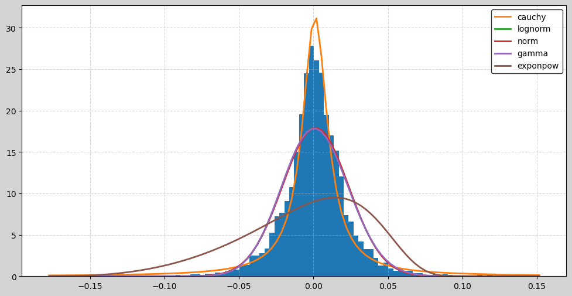

```python
dist = get_common_distributions() #get_distributions()#get_common_distributions()
f = Fitter(data.R, distributions=dist)
f.fit()
f.summary()
print("R")
print(f.get_best())
```

El rendimiento porcentual tiene una distribución cauchy, sin embargo, al la normal estar dentro de las primeras 3, podemos asumir que se distribuye normalmente

```
r
{'cauchy': {'loc': 0.0010685953886363211, 'scale': 0.0101143059306564}}
```

[output not shown]

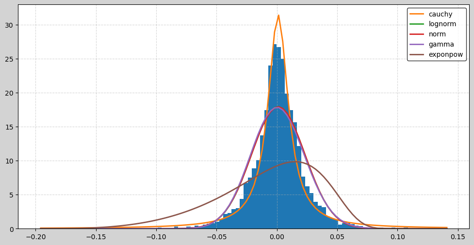

```python
dist= get_common_distributions() #get_distributions()#get_common_distributions()
f = Fitter(data.r, distributions=dist)
f.fit()
f.summary()
print("r")
print(f.get_best())
```

El rendimiento logarítmico tambien tiene una distribución cauchy, sin embargo, al la normal estar dentro de las primeras 3, podemos asumir que se distribuye normalmente

# Conclusiones

En primer lugar descargamos los datos historicos de Apple, pero al ver la distribución del histograma del precio, no logramos ver ninguna distribución aparente, por lo que procedimos a calcular los rendimientos.

Hay dos maneras principales de calcular los rendimientos, de manera porcentual y logarítmica. Ambos histogramas (R y r) tienen una forma aparentemente normal. Para tratar de encontrar diferencias se comparan las medias y varianzas de ambas distribuciones, pero se concluye que son iguales.

Después se pasan por una prueba de normalidad, en donde se puede ver que ninguno de los dos rendimientos tienen una distribución normal con el nivel de confianza del 95%.

Finalmente, se busca encontrar la distribución que más se ajuste a los datos y obtenemos que esta es la distribución Cauchy en mabos casos. No obstante al asemejarse a la distribución normal, se asume normalidad en la distribución de los rendimientos por conveniencia.